# EVALUATORY ASSIGNMENT

#### by Shivam Sharma

Our data is :*instagram-fake-spammer-genuine-accounts* We will do the follows: -

#### **Data Analysis**

We will first import the necessory libraries for data processing and visualization.

```python
import numpy as np # linear algebra
import pandas as pd # data processing, CSV file I/O (e.g. pd.read_csv)
import seaborn as sns
import matplotlib.pyplot as plt
import os
for dirname, _, filenames in os.walk('/kaggle/input'):
    for filename in filenames:
        print(os.path.join(dirname, filename))
import warnings
warnings.filterwarnings('ignore')
```

### Are we upto date, on the library versions?

```python
print(' PANDAS: -',pd.__version__,'\n NUMPY: -',np.__version__,'\n SEABORN: -',sns.__version__)
```

```
 PANDAS: - 1.1.3
 NUMPY: - 1.19.2
 SEABORN: - 0.11.0
```

# 1. DATA ANALYSIS

### Now We start by loading our data!

### Our data contains

Train.csv and Test.csv

```python
data_train = pd.read_csv('train.csv')
data_test = pd.read_csv('test.csv')
```

Lets see the data now

```python
data_train.head()
```

|  | profile pic | nums/length username | fullname words | nums/length fullname | name==username | description length | external URL | private | #posts | #followers | #follows | fake |
| --- | --- | --- | --- | --- | --- | --- | --- | --- | --- | --- | --- | --- |
| 0 | 1 | 0.27 | 0 | 0.0 | 0 | 53 | 0 | 0 | 32 | 1000 | 955 | 0 |
| 1 | 1 | 0.00 | 2 | 0.0 | 0 | 44 | 0 | 0 | 286 | 2740 | 533 | 0 |
| 2 | 1 | 0.10 | 2 | 0.0 | 0 | 0 | 0 | 1 | 13 | 159 | 98 | 0 |
| 3 | 1 | 0.00 | 1 | 0.0 | 0 | 82 | 0 | 0 | 679 | 414 | 651 | 0 |
| 4 | 1 | 0.00 | 2 | 0.0 | 0 | 0 | 0 | 1 | 6 | 151 | 126 | 0 |

```python
print(np.shape(data_train),np.shape(data_test)) #shows the shapes
```

```
(576, 12) (120, 12)
```

```python
data_train.isnull().any() #non of the values contain any null value
```

```
profile pic             False
nums/length username    False
fullname words          False
nums/length fullname    False
name==username          False
description length      False
external URL            False
private                 False
#posts                  False
#followers              False
#follows                False
fake                    False
dtype: bool
```

# 2. DATA PROCESSING AND VISUALIZATION

### 1. Thus max number of followers possessed by a user belonging to the group of users with no profile picture

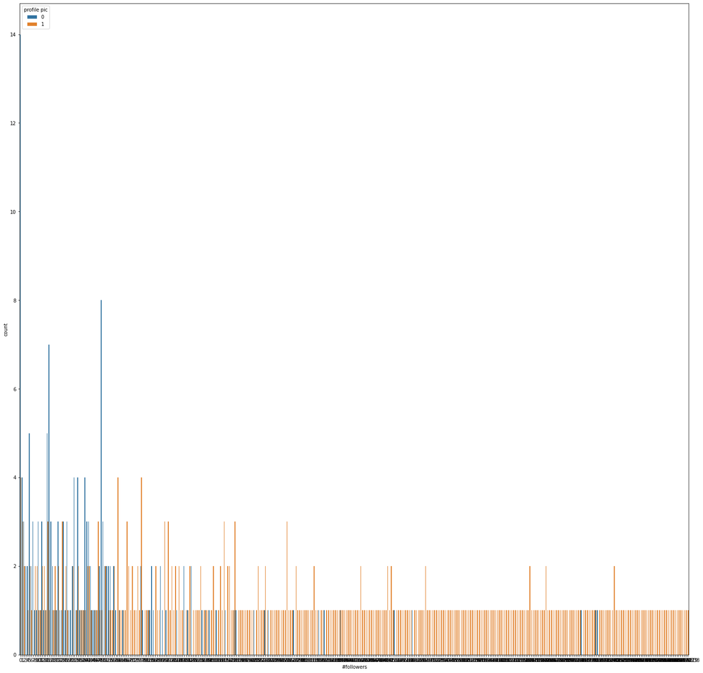

```python
plt.figure(figsize=(25, 25))

sns.countplot(x="#followers", data=data_train,hue="profile pic")
```

> Well, we cannot land to any conclusion with this data visualization. lets try to compute plots in smaller intervals and see if we could find any relevant information.

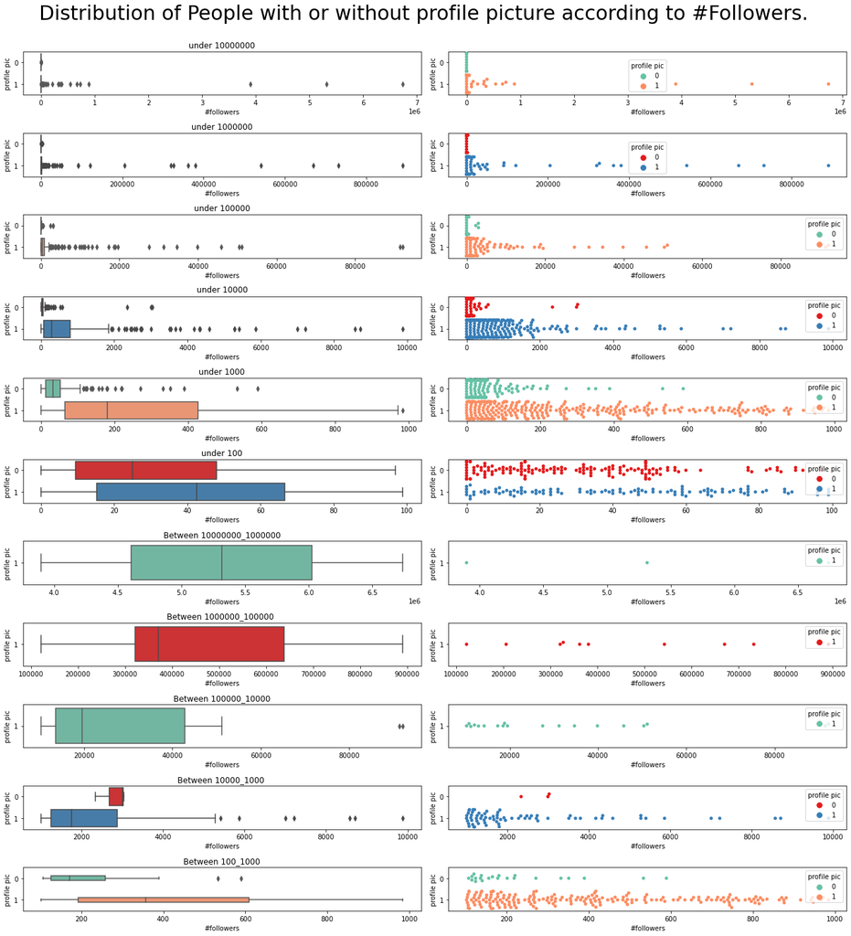

```python
##Max no. of followers by a user belonging to non profile picture category
data_follower_under_10000000 = data_train[data_train["#followers"]< 10000000] #under 10M
data_follower_under_1000000 = data_train[data_train["#followers"]< 1000000]#under 1M
data_follower_under_100000 = data_train[data_train["#followers"]< 100000]#under 1 lakhs
data_follower_under_10000 = data_train[data_train["#followers"]< 10000] #under 10 k
data_follower_under_1000 = data_train[data_train["#followers"]< 1000] #under 1k
data_follower_under_100 = data_train[data_train["#followers"]< 100] #under 100

data_follower_bewtween_10000000_1000000 = data_train[(data_train["#followers"]>1000000) & (data_train["#followers"]< 10000000)]#bewtween_10000000_1000000
data_follower_bewtween_1000000_100000 = data_train[(data_train["#followers"]>100000) & (data_train["#followers"]< 1000000)]#bewtween_1000000_100000
data_follower_bewtween_100000_10000 = data_train[(data_train["#followers"]>10000) & (data_train["#followers"]< 100000)] #bewtween_100000_10000
data_follower__bewtween_10000_1000 = data_train[(data_train["#followers"]>1000) & (data_train["#followers"]< 10000)] #bewtween_10000_1000
data_follower_bewtween_100_1000 = data_train[(data_train["#followers"]>100) & (data_train["#followers"]< 1000)]  #bewtween_100_1000

# Now making plots
fig, axes = plt.subplots(11, 2, figsize=(18,20), sharey=False)
fig.suptitle('Distribution of People with or without profile picture according to #Followers. \n',size=30)

axes[0][0].set_title("under 10000000",size=12)
axes[1][0].set_title("under 1000000",size=12)
axes[2][0].set_title("under 100000",size=12)
axes[3][0].set_title("under 10000",size=12)
axes[4][0].set_title("under 1000",size=12)
axes[5][0].set_title("under 100",size=12)
axes[6][0].set_title("Between 10000000_1000000",size=12)
axes[7][0].set_title("Between 1000000_100000 ",size=12)
axes[8][0].set_title("Between 100000_10000",size=12)
axes[9][0].set_title("Between 10000_1000 ",size=12)
axes[10][0].set_title("Between 100_1000",size=12)

sns.boxplot(ax=axes[0][0], data=data_follower_under_10000000 ,x="#followers",y="profile pic",orient='h',palette="Set2")
sns.boxplot(ax=axes[1][0], data=data_follower_under_1000000 ,x="#followers",y="profile pic",orient='h',palette="Set1")
sns.boxplot(ax=axes[2][0], data=data_follower_under_100000 ,x="#followers",y="profile pic",orient='h',palette="Set2")
sns.boxplot(ax=axes[3][0], data=data_follower_under_10000 ,x="#followers",y="profile pic",orient='h',palette="Set1")
sns.boxplot(ax=axes[4][0], data=data_follower_under_1000 ,x="#followers",y="profile pic",orient='h',palette="Set2")
sns.boxplot(ax=axes[5][0], data=data_follower_under_100 ,x="#followers",y="profile pic",orient='h',palette="Set1")
sns.boxplot(ax=axes[6][0], data=data_follower_bewtween_10000000_1000000 ,x="#followers",y="profile pic",orient='h',palette="Set2")
sns.boxplot(ax=axes[7][0], data=data_follower_bewtween_1000000_100000 ,x="#followers",y="profile pic",orient='h',palette="Set1")
sns.boxplot(ax=axes[8][0], data=data_follower_bewtween_100000_10000 ,x="#followers",y="profile pic",orient='h',palette="Set2")
sns.boxplot(ax=axes[9][0], data=data_follower__bewtween_10000_1000 ,x="#followers",y="profile pic",orient='h',palette="Set1")
sns.boxplot(ax=axes[10][0], data=data_follower_bewtween_100_1000 ,x="#followers",y="profile pic",orient='h',palette="Set2",dodge =False,width=.2)
sns.swarmplot(ax=axes[0][1], data=data_follower_under_10000000 ,x="#followers",y="profile pic",orient='h',hue="profile pic",palette="Set2")
sns.swarmplot(ax=axes[1][1], data=data_follower_under_1000000 ,x="#followers",y="profile pic",orient='h',hue="profile pic",palette="Set1")
sns.swarmplot(ax=axes[2][1], data=data_follower_under_100000 ,x="#followers",y="profile pic",orient='h',hue="profile pic",palette="Set2")
sns.swarmplot(ax=axes[3][1], data=data_follower_under_10000 ,x="#followers",y="profile pic",orient='h',hue="profile pic",palette="Set1")
sns.swarmplot(ax=axes[4][1], data=data_follower_under_1000 ,x="#followers",y="profile pic",orient='h',hue="profile pic",palette="Set2")
sns.swarmplot(ax=axes[5][1], data=data_follower_under_100 ,x="#followers",y="profile pic",orient='h',hue="profile pic",palette="Set1")
sns.swarmplot(ax=axes[6][1], data=data_follower_bewtween_10000000_1000000 ,x="#followers",y="profile pic",orient='h',hue="profile pic",palette="Set2")
sns.swarmplot(ax=axes[7][1], data=data_follower_bewtween_1000000_100000 ,x="#followers",y="profile pic",orient='h',hue="profile pic",palette="Set1")
sns.swarmplot(ax=axes[8][1], data=data_follower_bewtween_100000_10000 ,x="#followers",y="profile pic",orient='h',hue="profile pic",palette="Set2")
sns.swarmplot(ax=axes[9][1], data=data_follower__bewtween_10000_1000 ,x="#followers",y="profile pic",orient='h',hue="profile pic",palette="Set1")
sns.swarmplot(ax=axes[10][1], data=data_follower_bewtween_100_1000 ,x="#followers",y="profile pic",orient='h',hue="profile pic",palette="Set2")

fig.tight_layout()
```

## What could be infered from this ?

> These plots validate the fact that as #followers increases the number of accounts without profile picture decreases.

Now we can say that the account with greatest value of followers without profile will be near lower values of #followers

We query our data to get the max number of followers possessed by a user belonging to the group of users with no profile picture.

```python
print("Thus max number of followers possessed by a user belonging to the group of users with no profile picture =>",data_train[data_train['profile pic']==0]['#followers'].max()) # no profile pic and the maximum followers
```

```
Thus max number of followers possessed by a user belonging to the group of users with no profile picture => 3033
```

### Lets check out the whole row of that person/people with 3033 followers and having no profile picture.

```python
data_train[data_train["#followers"] == 3033] #also check there are no multpile accounts under same constraint!
```

|  | profile pic | nums/length username | fullname words | nums/length fullname | name==username | description length | external URL | private | #posts | #followers | #follows | fake |
| --- | --- | --- | --- | --- | --- | --- | --- | --- | --- | --- | --- | --- |
| 530 | 0 | 0.18 | 1 | 0.0 | 0 | 0 | 0 | 0 | 0 | 3033 | 1155 | 1 |

What about the account with profile pictures, lets check on that list for max followers

```python
print("We get to know that => Followers are",data_train[data_train['profile pic']==1]['#followers'].max())
```

```
We get to know that => Followers are 15338538
```

Both the queries results can be easily validated from the above charts of #followers with or without profile picture.

### 2. Dead accounts are represented by their numeber of posts, description length and if they have a profile picture or not. Using the same structure for querying we can get number of dead accounts from our data set(train data set).

```python
data_train[(data_train['profile pic']==0)&(data_train['#posts']==0)&(data_train['description length']==0)]
# No profile picture,  No posts and a zero description length.
```

|  | profile pic | nums/length username | fullname words | nums/length fullname | name==username | description length | external URL | private | #posts | #followers | #follows | fake |
| --- | --- | --- | --- | --- | --- | --- | --- | --- | --- | --- | --- | --- |
| 288 | 0 | 0.22 | 1 | 0.00 | 0 | 0 | 0 | 0 | 0 | 90 | 333 | 1 |
| 289 | 0 | 0.38 | 1 | 0.00 | 0 | 0 | 0 | 0 | 0 | 60 | 31 | 1 |
| 293 | 0 | 0.31 | 2 | 0.00 | 0 | 0 | 0 | 0 | 0 | 39 | 64 | 1 |
| 295 | 0 | 0.00 | 1 | 0.00 | 0 | 0 | 0 | 1 | 0 | 0 | 853 | 1 |
| 297 | 0 | 0.00 | 2 | 0.00 | 0 | 0 | 0 | 0 | 0 | 12 | 5 | 1 |
| ... | ... | ... | ... | ... | ... | ... | ... | ... | ... | ... | ... | ... |
| 552 | 0 | 0.46 | 1 | 0.00 | 0 | 0 | 0 | 1 | 0 | 332 | 1333 | 1 |
| 553 | 0 | 0.73 | 1 | 0.00 | 0 | 0 | 0 | 0 | 0 | 14 | 542 | 1 |
| 556 | 0 | 0.31 | 1 | 0.31 | 1 | 0 | 0 | 0 | 0 | 26 | 27 | 1 |
| 561 | 0 | 0.86 | 2 | 0.18 | 0 | 0 | 0 | 0 | 0 | 57 | 130 | 1 |
| 562 | 0 | 0.62 | 1 | 0.00 | 0 | 0 | 0 | 1 | 0 | 58 | 347 | 1 |

123 rows × 12 columns

```python
dead_acc = data_train[(data_train['profile pic']==0)&(data_train['#posts']==0)&(data_train['description length']==0)].shape[0]
print("The number of dead accounts according to our constraint are ->",dead_acc)
```

```
The number of dead accounts according to our constraint are -> 123
```

### We can also infer something if we try to visualise the data with fake accounts :

> We see that a dead account has higher probability of being a fake account!

```python
data_trainning = data_train
data_trainning["is_dead"] = np.where( (data_train['profile pic']==0)&(data_train['#posts']==0)&(data_train['description length']==0),1,0)
```

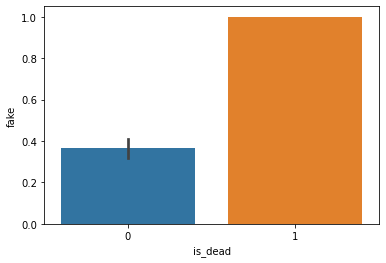

```python
ax = sns.barplot(x="is_dead", y="fake", data=data_trainning)
#This shows that a dead account has higher probability of being a fake account!
```

## This shows that a dead account has higher probability of being a fake account!

## 3. An expressive or an non-expressive user?

An user is said to be expreessive if he/she has a description length above then average, but first we need to know about the average value of a description length from our data.

So we use .describe method

```python
data_train.describe()
```

|  | profile pic | nums/length username | fullname words | nums/length fullname | name==username | description length | external URL | private | #posts | #followers | #follows | fake | is_dead |
| --- | --- | --- | --- | --- | --- | --- | --- | --- | --- | --- | --- | --- | --- |
| count | 576.000000 | 576.000000 | 576.000000 | 576.000000 | 576.000000 | 576.000000 | 576.000000 | 576.000000 | 576.000000 | 5.760000e+02 | 576.000000 | 576.000000 | 576.000000 |
| mean | 0.701389 | 0.163837 | 1.460069 | 0.036094 | 0.034722 | 22.623264 | 0.116319 | 0.381944 | 107.489583 | 8.530724e+04 | 508.381944 | 0.500000 | 0.213542 |
| std | 0.458047 | 0.214096 | 1.052601 | 0.125121 | 0.183234 | 37.702987 | 0.320886 | 0.486285 | 402.034431 | 9.101485e+05 | 917.981239 | 0.500435 | 0.410163 |
| min | 0.000000 | 0.000000 | 0.000000 | 0.000000 | 0.000000 | 0.000000 | 0.000000 | 0.000000 | 0.000000 | 0.000000e+00 | 0.000000 | 0.000000 | 0.000000 |
| 25% | 0.000000 | 0.000000 | 1.000000 | 0.000000 | 0.000000 | 0.000000 | 0.000000 | 0.000000 | 0.000000 | 3.900000e+01 | 57.500000 | 0.000000 | 0.000000 |
| 50% | 1.000000 | 0.000000 | 1.000000 | 0.000000 | 0.000000 | 0.000000 | 0.000000 | 0.000000 | 9.000000 | 1.505000e+02 | 229.500000 | 0.500000 | 0.000000 |
| 75% | 1.000000 | 0.310000 | 2.000000 | 0.000000 | 0.000000 | 34.000000 | 0.000000 | 1.000000 | 81.500000 | 7.160000e+02 | 589.500000 | 1.000000 | 0.000000 |
| max | 1.000000 | 0.920000 | 12.000000 | 1.000000 | 1.000000 | 150.000000 | 1.000000 | 1.000000 | 7389.000000 | 1.533854e+07 | 7500.000000 | 1.000000 | 1.000000 |

## --More clearly the mean is --

```python
data_train['description length'].mean(axis=0)
```

```
22.62326388888889
```

> We get to know that the average length of an instagram bio should be greater than 22 words, max is 150 words and min is 0 words. Taking this as our basis we can divide our data into : non-expressive if desc_len is in between 0- 22 and expressive if desc_len is in between 22-150.

```python
data_exp_non_exp = data_train
data_exp_non_exp["Expressive?"] = np.where(data_exp_non_exp['description length'] >22,'Expressive','Non-Expressive')
```

```python
data_exp_non_exp
```

|  | profile pic | nums/length username | fullname words | nums/length fullname | name==username | description length | external URL | private | #posts | #followers | #follows | fake | is_dead | Expressive? |
| --- | --- | --- | --- | --- | --- | --- | --- | --- | --- | --- | --- | --- | --- | --- |
| 0 | 1 | 0.27 | 0 | 0.00 | 0 | 53 | 0 | 0 | 32 | 1000 | 955 | 0 | 0 | Expressive |
| 1 | 1 | 0.00 | 2 | 0.00 | 0 | 44 | 0 | 0 | 286 | 2740 | 533 | 0 | 0 | Expressive |
| 2 | 1 | 0.10 | 2 | 0.00 | 0 | 0 | 0 | 1 | 13 | 159 | 98 | 0 | 0 | Non-Expressive |
| 3 | 1 | 0.00 | 1 | 0.00 | 0 | 82 | 0 | 0 | 679 | 414 | 651 | 0 | 0 | Expressive |
| 4 | 1 | 0.00 | 2 | 0.00 | 0 | 0 | 0 | 1 | 6 | 151 | 126 | 0 | 0 | Non-Expressive |
| ... | ... | ... | ... | ... | ... | ... | ... | ... | ... | ... | ... | ... | ... | ... |
| 571 | 1 | 0.55 | 1 | 0.44 | 0 | 0 | 0 | 0 | 33 | 166 | 596 | 1 | 0 | Non-Expressive |
| 572 | 1 | 0.38 | 1 | 0.33 | 0 | 21 | 0 | 0 | 44 | 66 | 75 | 1 | 0 | Non-Expressive |
| 573 | 1 | 0.57 | 2 | 0.00 | 0 | 0 | 0 | 0 | 4 | 96 | 339 | 1 | 0 | Non-Expressive |
| 574 | 1 | 0.57 | 1 | 0.00 | 0 | 11 | 0 | 0 | 0 | 57 | 73 | 1 | 0 | Non-Expressive |
| 575 | 1 | 0.27 | 1 | 0.00 | 0 | 0 | 0 | 0 | 2 | 150 | 487 | 1 | 0 | Non-Expressive |

576 rows × 14 columns

```python
data_exp_non_exp[data_exp_non_exp["Expressive?"] == "Expressive"].shape
```

```
(182, 14)
```

### Thus 182 people arefound to be more expressive then the average.

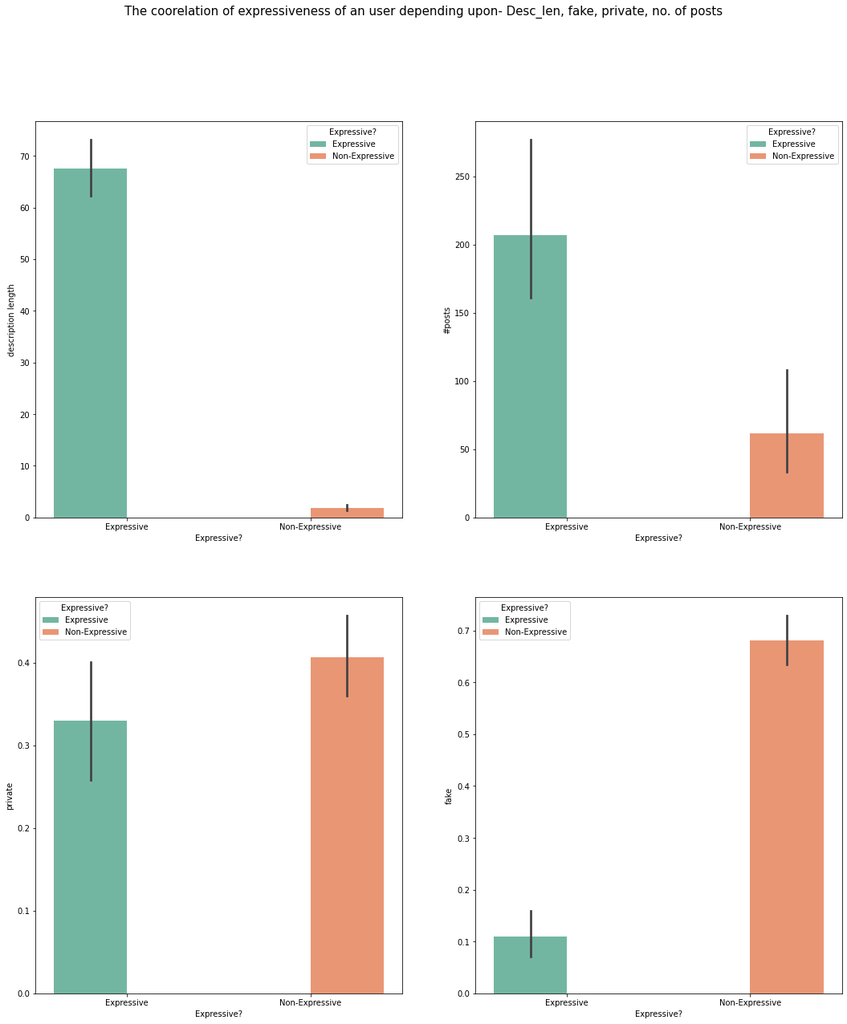

```python
fig, axes = plt.subplots(2, 2, figsize=(18,20), sharey=False)
fig.suptitle('The coorelation of expressiveness of an user depending upon- Desc_len, fake, private, no. of posts \n',size=15)


sns.barplot(ax=axes[0][0] ,x="Expressive?",y="description length",hue="Expressive?",data=data_exp_non_exp,palette="Set2")
sns.barplot(ax=axes[1][1] ,x="Expressive?",y="fake",hue="Expressive?",data=data_exp_non_exp,palette="Set2")
sns.barplot(ax=axes[1][0] ,x="Expressive?",y="private",hue="Expressive?",data=data_exp_non_exp,palette="Set2")
sns.barplot(ax=axes[0][1] ,x="Expressive?",y="#posts",hue="Expressive?",data=data_exp_non_exp,palette="Set2")
```

### From this representation we see that if a person is expressive he/she also has more number of posts, is lower chances of having account private and also lower chances of being a fake user.

## 4. Max no. of followers possessed by a user among those who have 0 posts.

```python
data_train[data_train['#posts']==0]['#followers'].max()
```

```
3033
```

## 5. Ratio of number of followers (#followers) to number of following (#follows) for the user with the maximum number of following

```python
data_train['#follows'].max() #the row/user for which there is max number of followers
```

```
7500
```

```python
data_followers = data_train[data_train['#follows']==7500] # lets check if there are multpile entries.
```

```python
data_followers
```

|  | profile pic | nums/length username | fullname words | nums/length fullname | name==username | description length | external URL | private | #posts | #followers | #follows | fake | is_dead | Expressive? |
| --- | --- | --- | --- | --- | --- | --- | --- | --- | --- | --- | --- | --- | --- | --- |
| 130 | 1 | 0.0 | 4 | 0.0 | 0 | 150 | 1 | 0 | 161 | 1383 | 7500 | 0 | 0 | Expressive |
| 276 | 1 | 0.0 | 1 | 0.0 | 0 | 30 | 0 | 1 | 103 | 1775 | 7500 | 0 | 0 | Expressive |

```python
print("for user 130--> ratio is : ", 1383/7500)
print("for user 276--> ratio is : ", 1775/7500)
```

```
for user 130--> ratio is :  0.1844
for user 276--> ratio is :  0.23666666666666666
```